# Proyecto: BN (Aprendizaje Máquina II)

Máster Ciencia de Datos UV

Carlos Sánchez Polo y Jesús Martínez Leal

2024-03-17

Como es habitual, cargamos las librerías que necesitamos al inicio del documento.

# Objetivo

El trabajo consiste en la creación de la *Red Bayesiana* `Garaje` y realizar ejercicios de inferencia. Se hará uso de los paquetes `bnlearn` y `gRain`.

Un taller dispone de una *Red Bayesiana* para modelizar las probabilidades de su día a día. Los vehículos están caracterizados con las variables Edad (A), Tipo (T), Kilometraje (M) y si necesitan cambios de bujías (SP) y/o frenos (B).

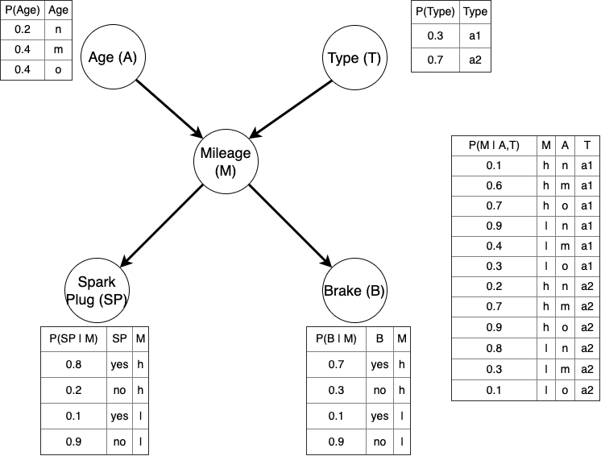

Figura 1. Esquema de la red bayesiana del garaje.

# Red Bayesiana

## Distribución de probabilidad

Empezaremos escribiendo de manera factorizada la probabilidad conjunta $P(A, T, M, SP, B)$.

Para hallar la distribución de probabilidad conjunta podemos reescribirla a partir de productos de distribuciones condicionados siguiendo la `regla de la cadena`. Así pues, a partir de la imagen proporcionada se deduce que:

$P(A,T,M,SP,B)= P(A) \times P(T) \times P(M|A, T) \times P(SP | M) \times P(B|M)$

## Grafo Acíclico Dirigido

Vamos a crear el grafo acíclico dirigido. Para ello empelamos la función `model2network`.

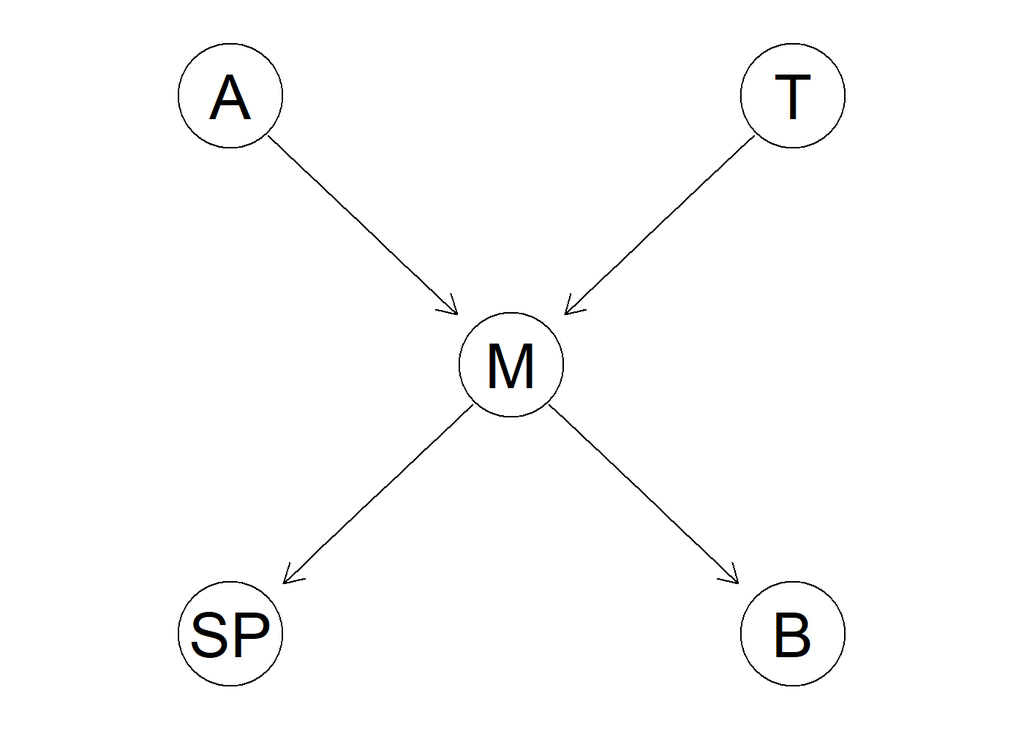

Figure 2. Grafo acíclico dirigido creado con `model2ntetwork`

Unas preguntas básicas serían si es acíclico, dirigido y cuáles son los nodos raíz:

```
[1] TRUE
```

```
[1] TRUE
```

```
[1] "A" "T"
```

Efectivamente, nuestro grafo es acíclico y dirigido (DAG).

El término `dirigido` indica que las aristas tienen una dirección definida, significando que hay una distinción entre el nodo origen y el nodo destino para cada arista. Esto implica que si por ejemplo una arista va del nodo A al B, hay una relación de influencia de A hacia B, pero no necesariamente de B a A.

El término `acíclico` por otra parte indica que noe xisten ciclos, no hay una secuencia de aristas que pueda llevarnos de regreso al mismo nodo siguiendo la dirección de las aristas.

## CPT, Tablas de probabilidad condicionada

En primer lugar, creamos las matrices/arrays de probabilidad condicionada para cada nodo. Se muestra el código también de manera explícita en el documento de HTML.

```r
# Nodo raíz A
A.lv <- c("n", "m", "o")
A.prob <- array(c(0.2, 0.4, 0.4), dim = 3, dimnames = list(A = A.lv))
A.prob
```

```
A
  n   m   o
0.2 0.4 0.4
```

```r
# Nodo raíz T
T.lv <- c("a1", "a2")
T.prob <- array(c(0.3, 0.7), dim = 2, dimnames = list(T = T.lv))
T.prob
```

```
T
 a1  a2
0.3 0.7
```

```r
# Nodo M
M.lv <- c("h", "l")
M.prob <- array(c(0.1, 0.9, 0.6, 0.4, 0.7, 0.3, 0.2, 0.8, 0.7, 0.3, 0.9, 0.1), dim = c(2, 3, 2), dimnames = list(M = M.lv,
    A = A.lv, T = T.lv))
ftable(M.prob, row.vars = c(3, 2), col.vars = 1)
```

```
     M   h   l
T  A
a1 n   0.1 0.9
   m   0.6 0.4
   o   0.7 0.3
a2 n   0.2 0.8
   m   0.7 0.3
   o   0.9 0.1
```

```r
# Nodo SP
SP.lv <- c("yes", "no")
SP.prob <- array(c(0.8, 0.2, 0.1, 0.9), dim = c(2, 2), dimnames = list(SP = SP.lv, M = M.lv))
SP.prob
```

```
     M
SP      h   l
  yes 0.8 0.1
  no  0.2 0.9
```

```r
# Nodo B
B.lv <- c("yes", "no")
B.prob <- array(c(0.7, 0.3, 0.1, 0.9), dim = c(2, 2), dimnames = list(B = B.lv, M = M.lv))
B.prob
```

```
     M
B       h   l
  yes 0.7 0.1
  no  0.3 0.9
```

Una vez hecho esto, solo necesitamos crear una lista con todos estos arrays: eso es nuestro `cpt`.

## Red Bayesiana

Unimos el grafo y las distribuciones locales para crear la *Red Bayesiana*. Para ello, utilizamos la función `custom.fit`.

```
  Bayesian network parameters

  Parameters of node A (multinomial distribution)

Conditional probability table:
 A
  n   m   o
0.2 0.4 0.4

  Parameters of node T (multinomial distribution)

Conditional probability table:
 T
 a1  a2
0.3 0.7

  Parameters of node M (multinomial distribution)

Conditional probability table:

, , T = a1

   A
M     n   m   o
  h 0.1 0.6 0.7
  l 0.9 0.4 0.3

, , T = a2

   A
M     n   m   o
  h 0.2 0.7 0.9
  l 0.8 0.3 0.1


  Parameters of node SP (multinomial distribution)

Conditional probability table:

     M
SP      h   l
  yes 0.8 0.1
  no  0.2 0.9

  Parameters of node B (multinomial distribution)

Conditional probability table:

     M
B       h   l
  yes 0.7 0.1
  no  0.3 0.9
```

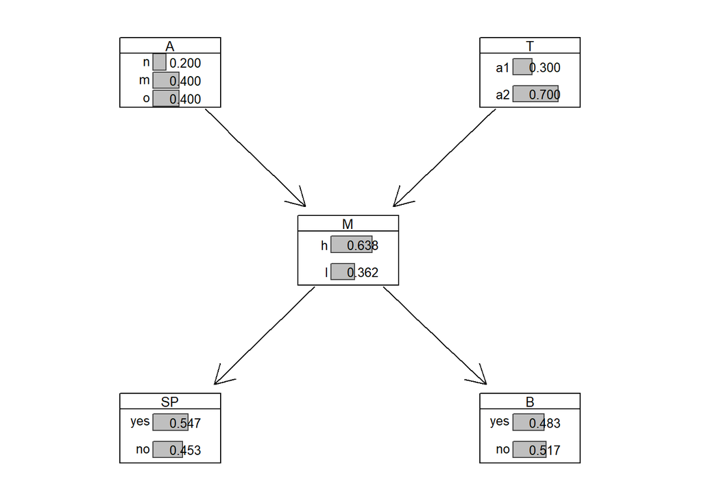

Figure 3. Red bayesiana con probabilidades a priori marginales.

# Inferencia

## Creación del Junction Tree

Creamos el árbol de inferencia `junction tree` para acelerar los cálculos de las probabilidades condicionadas de manera exacta.

El árbol de inferencia proporciona una forma eficiente de realizar estos cálculos al dividir la red bayesiana en subgrafos más pequeños y conectados llamados “cliques”, que son conjuntos de nodos completamente conectados entre sí. Estos cliques se combinan de manera jerárquica para formar un árbol, donde cada nodo del árbol representa un clique y cada arista del árbol representa la unión de dos cliques.

## Razonamiento sin Evidencias

### Determina las probabilidades del Kilometraje de los vehículos, `P(M)`, sin ninguna información adicional (evidencias). ¿Hay algún resultado más esperable que otro?

Matemáticamente, esto sería $P(M) = \sum_{a, t} \ P(M|A, T) \ P(A = a) P (T = t)$. Se pone el cálculo realizado a mano explícitamente que permite verificar que esta expresión es la correcta.

```r
pMh_amano <- (0.1 * 0.3 * 0.2 + 0.6 * 0.3 * 0.4 + 0.7 * 0.3 * 0.4 + 0.2 * 0.7 * 0.2 + 0.7 * 0.7 * 0.4 +
    0.9 * 0.7 * 0.4)/(0.1 * 0.3 * 0.2 + 0.6 * 0.3 * 0.4 + 0.7 * 0.3 * 0.4 + 0.2 * 0.7 * 0.2 + 0.7 * 0.7 *
    0.4 + 0.9 * 0.7 * 0.4 + 0.9 * 0.3 * 0.2 + 0.4 * 0.3 * 0.4 + 0.3 * 0.3 * 0.4 + 0.8 * 0.7 * 0.2 + 0.3 *
    0.7 * 0.4 + 0.1 * 0.7 * 0.4)

pMl_amano <- 1 - pMh_amano

pMh_amano
```

```
[1] 0.638
```

```r
pMl_amano
```

```
[1] 0.362
```

Obviamente, esto es mucho más cómodo de calcular con la función `querygrain`.

```r
P_M <- querygrain(jt, nodes = "M", type = "marginal")
P_M
```

```
$M
M
    h     l
0.638 0.362
```

Resulta más esperable que tenga un valor de `h` (high) (kilometraje alto) que bajo `l` (low).

### Determina las probabilidades del Kilometraje, $M$, cuando la condicionamos al tipo, $T$. ¿observas cambios en los resultados del Kilometraje?

```r
pM_T <- querygrain(jt, nodes = c("M", "T"), type = "conditional")
pM_T
```

```
   T
M     a1   a2
  h 0.54 0.68
  l 0.46 0.32
```

Al condicionar el kilometraje `M` con el tipo de vehículo `T` observamos cambios, puesto que hay una influencia. En ambos tipos de vehículos `a1` y `a2` se da que la categoría más frecuente para `M` es `h`. Sin embargo, puede apreciarse como para el segundo tipo, `a2`, hay un porcentaje más alto de vehículos con `M = h`.

### Recupera la distribución de probabilidad CONJUNTA de TODAS las variables del problema. ¿cuál es la situación más probable (MAP)?

Para esto utilizamos el `type` en `querygrain` correspondiente a `joint`. El resultado se muestra a continuación haciendo además uso de `ftable()`, de forma que pueda visualizarse mejor la tabla de contingencia para todas las variables disponibles.

```r
p_joint <- querygrain(jt, type = "joint")
table_joint <- ftable(p_joint)
table_joint
```

```
           B     yes      no
A M T  SP
n h a1 yes   0.00336 0.00144
       no    0.00084 0.00036
    a2 yes   0.01568 0.00672
       no    0.00392 0.00168
  l a1 yes   0.00054 0.00486
       no    0.00486 0.04374
    a2 yes   0.00112 0.01008
       no    0.01008 0.09072
m h a1 yes   0.04032 0.01728
       no    0.01008 0.00432
    a2 yes   0.10976 0.04704
       no    0.02744 0.01176
  l a1 yes   0.00048 0.00432
       no    0.00432 0.03888
    a2 yes   0.00084 0.00756
       no    0.00756 0.06804
o h a1 yes   0.04704 0.02016
       no    0.01176 0.00504
    a2 yes   0.14112 0.06048
       no    0.03528 0.01512
  l a1 yes   0.00036 0.00324
       no    0.00324 0.02916
    a2 yes   0.00028 0.00252
       no    0.00252 0.02268
```

Para hallar la situación más probable simplemente tendremos que ver la combinación con mayor valor en la distribución de probabilidad conjunta.

```r
max_value_index <- which.max(table_joint)
max_value <- max(table_joint)

print(paste("El máximo valor de la tabla de probabilidad conjunta es", max_value, ", hallándose en la fila",
    max_value_index))
```

```
[1] "El máximo valor de la tabla de probabilidad conjunta es 0.14112 , hallándose en la fila 19"
```

Un rápido vistazo nos hace ver que esto se da con: `P(A = o, T = a2, M = h, SP = yes, B = yes)`.

## Razonamiento con Evidencias

Se utilizará la función `setEvidence` del paquete `gRain` para estos cálculos.

### Determina la probabilidad de la evidencia `E = {A = n, T = a2, M = l, SP = yes, B = yes}`. Interpreta el resultado.

```r
evidence <- setEvidence(jt, evidence = list(A = "n", T = "a2", M = "l", SP = "yes", B = "yes"))

pEvidence(evidence)
```

```
[1] 0.00112
```

Esta corresponde a la probabilidad de la distribución conjunta dados esos valores particulares, tal y como puede verse en el resultado de la probabilidad conjunta anterior.

### Determina cómo se modifica la probabilidad de cambiar los frenos, `B = yes`, si sabemos que el vehículo es viejo, `A = o`. ¿Aumenta o disminuye? ¿(según las diapositivas de clase) es razonamiento evidencial o causal?

```r
probB_priori <- querygrain(jt, nodes = "B", type = "marginal")
names(probB_priori) <- "Probabilidad priori de B"
probB_priori
```

```
$`Probabilidad priori de B`
B
   yes     no
0.4828 0.5172
```

```r
jt_Ao <- setEvidence(jt, nodes = c("A"), states = "o")
probB_ev <- querygrain(jt_Ao, nodes = c("B"), type = "marginal")  # marginal y conditional arrojan igual resultado, ya que solo está esa en `nodes`
names(probB_ev) <- "Probabilidad de B condicionada a que A = o"
probB_ev
```

```
$`Probabilidad de B condicionada a que A = o`
B
  yes    no
0.604 0.396
```

Si el vehículo es viejo (`A = o`) vemos que la probabilidad de que haya que cambiar los frenos (`B = yes`) se ve incrementada (segundo caso frente al primero). Esto tiene lógica con lo que cabríamos esperar: un vehículo viejo tiene sentido que aumente su probabilidad de necesitar un cambio de frenos. En este caso se trata de un razonamiento causal, puesto que se trata de un tipo de razonamiento “descendente”, puesto que especifica cómo la causa genera el efecto.

### Determina cómo se modifica la probabilidad de que el vehículo es nuevo, `A = n`, cuando sabemos que necesita un cambio de bujías y de frenos, `SP = yes, B = yes`. ¿(según las diapositivas de clase) es razonamiento evidencial o causal?

```r
probA_priori <- querygrain(jt, nodes = "A", type = "marginal")
names(probA_priori) <- "Probabilidad priori de A"
probA_priori
```

```
$`Probabilidad priori de A`
A
  n   m   o
0.2 0.4 0.4
```

```r
jt_SPyBy <- setEvidence(jt, evidence = list(SP = "yes", B = "yes"))
probsA_ev <- querygrain(jt_SPyBy, nodes = c("A"), type = "marginal")
names(probsA_ev) <- "Probabilidad de A condicionada a que SP = yes y B = yes"
probsA_ev
```

```
$`Probabilidad de A condicionada a que SP = yes y B = yes`
A
         n          m          o
0.05735661 0.41950679 0.52313660
```

```r
# cond <- querygrain(jt, nodes = c('A', 'SP', 'B'), type = 'conditional') Nota: estos resultados
# también podrían deducirse a partir de aquí, pero no es tan inmediato. ftable(cond)
```

Vemos que si necesita cambio de bujía y frenos incrementa la probabilidad de que sea viejo, disminuyendo la de que sea nuevo. En este caso afrontamos un razonamiento diagnóstico/evidencial (razonamiento “ascendente”), ya que vamos desde los efectos a las causas.

### Determina cómo se modifica la probabilidad de la edad del vehículo, `A`, cuando sabemos que Kilometraje es alto, `SM = h`, dependiendo del tipo de vehículo `T`.

```r
jt_Mh <- setEvidence(jt, nodes = "M", states = "h")

probA_evT <- querygrain(jt_Mh, nodes = c("A", "T"), type = "conditional")  # aquí sí necesitamos la condicional, teniendo dos nodos.
print("Probabilidad de A condicionada a T, sabiendo SM = h")
```

```
[1] "Probabilidad de A condicionada a T, sabiendo SM = h"
```

```r
probA_evT
```

```
   T
A           a1         a2
  n 0.03703704 0.05882353
  m 0.44444444 0.41176471
  o 0.51851852 0.52941176
```

# Conclusiones del uso de una red bayesiana

Las redes bayesianas nos han permitido modelar de manera explícita y completa las relaciones probabilísticas entre variables, facilitando la comprensión e inferencia. Resultan además extremadamente flexibles dada su actualización con evidencia adicional en forma de datos observados o suposiciones del dominio, permitiendo que las inferencias se ajusten dinámicamente a medida que se adquiere nueva información.